# Description of Inter-Item Timings (IRTs)

Tyler Peckenpaugh

3/29/2019

# Inter-item timing

Subjects were asked to read each sentence twice, once with no preview at all, and then again after unlimited preview. Inter-reading time (IRT) is a measure of the amount of time between when a subject stops speaking after a cold reading and when they begin speaking for a previewed reading.

> IRT = delay after the end of a cold reading and before the start of a previewed reading

Practically, this was done over 1515 recordings (33 participants, 48 items = 1584 pairs, with 69 missing data). This was measured using Google’s WebRTC Voice Activity Detection (VAD) over .wav files that had been subjected to a band-pass filter with a low threshold of 200Hz and a high threshold of 3100Hz.

a low hum in the room needed to be accounted for

## Description and cleanup

The following section details the IRT data and the outlier removal and resulting participant attrition.

## Distribution of IRTs, all participants

The overal mean IRT for all participants, all items (including fillers), and all conditions is 6982.88ms (sd = 4351.97). The highest IRT was 35792ms.

[figure not shown]

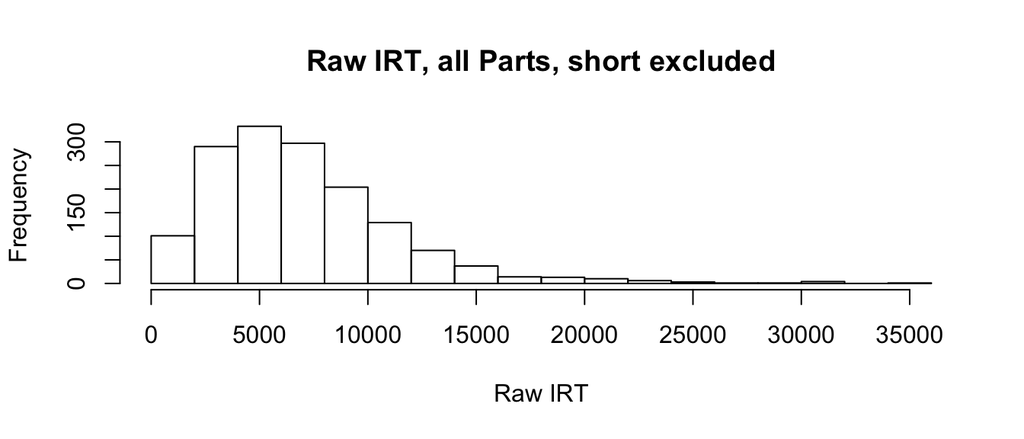

## Missing data and attrition

Due to noise in recordings and/or technical difficulties during data collection, a number of IRTs are missing for experimental items in the data. The following table shows which participants are missing how many IRTs; ideally each would have 48 IRTs and 16 experimental IRTs.

Mising data, by participant

|  | Missing IRTs | Available % of IRTs | Missing experimental IRTs | Available % of experimental IRTs |
| --- | --- | --- | --- | --- |
| 1 | 1 | 97.92% | 0 | 100% |
| 2 | 3 | 93.75% | 1 | 93.75% |
| 3 | 3 | 93.75% | 1 | 93.75% |
| 4 | 6 | 87.5% | 3 | 81.25% |
| 5 | 25 | 47.92% | 8 | 50% |
| 6 | 1 | 97.92% | 1 | 93.75% |
| 7 | 0 | 100% | 0 | 100% |
| 8 | 10 | 79.17% | 4 | 75% |
| 9 | 0 | 100% | 0 | 100% |
| 10 | 0 | 100% | 0 | 100% |
| 11 | 13 | 72.92% | 5 | 68.75% |
| 12 | 2 | 95.83% | 0 | 100% |
| 13 | 1 | 97.92% | 1 | 93.75% |
| 14 | 0 | 100% | 0 | 100% |
| 15 | 0 | 100% | 0 | 100% |
| 16 | 0 | 100% | 0 | 100% |
| 17 | 0 | 100% | 0 | 100% |
| 19 | 1 | 97.92% | 2 | 87.5% |
| 20 | 0 | 100% | 0 | 100% |
| 21 | 1 | 97.92% | 0 | 100% |
| 22 | 0 | 100% | 0 | 100% |
| 201 | 0 | 100% | 0 | 100% |
| 203 | 0 | 100% | 0 | 100% |
| 204 | 0 | 100% | 0 | 100% |
| 205 | 0 | 100% | 0 | 100% |
| 206 | 0 | 100% | 0 | 100% |
| 207 | 0 | 100% | 0 | 100% |
| 208 | 0 | 100% | 0 | 100% |
| 209 | 1 | 97.92% | 0 | 100% |
| 210 | 0 | 100% | 0 | 100% |
| 212 | 0 | 100% | 0 | 100% |
| 214 | 1 | 97.92% | 1 | 93.75% |
| 215 | 0 | 100% | 0 | 100% |

The 2 participants missing more than 4 experimental IRTs (5, 11) are excluded.

## Group sizes after attrition

The following table shows how the participants are distributed across groupsafter attrition. Ideally, there would be 4 per group-order cell, but because of attrition the cells are uneven. Because regression is able to account for uneven groups, this defect will hopefully not play an important role in the analyses that follow.

There is 5 in Group 1, Split BA because I ran four participants per group-order, and then one extra who happened to be assigned to group 1, split BA; and by happenstance, none of the participants from that cell needed to be excluded.

Group/order totals after attrition

|  | Split AB | Split BA | Group Total |
| --- | --- | --- | --- |
| Group 1 | 3 | 5 | 8 |
| Group 2 | 4 | 4 | 8 |
| Group 3 | 4 | 4 | 8 |
| Group 4 | 3 | 4 | 7 |
| Split Total | 14 | 17 | 31 |

## Distribution of experimental item IRT after attrition

The following histograms show the distribution of experimental item IRTs after attrition, and then the Winsorized IRTs, and finally the common log of winsorized IRTs, which are the shape of the data most suited to regression analyses.

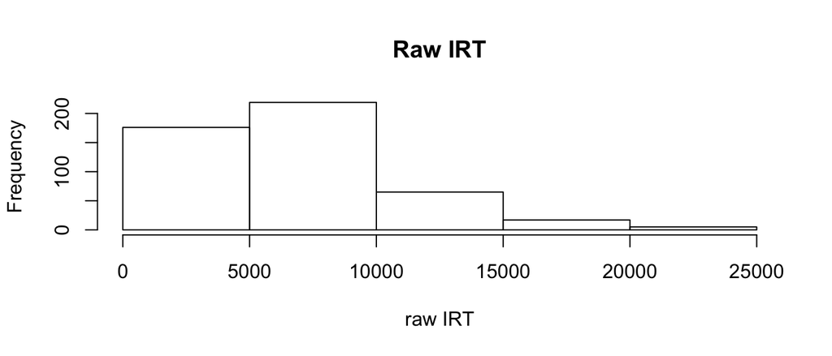

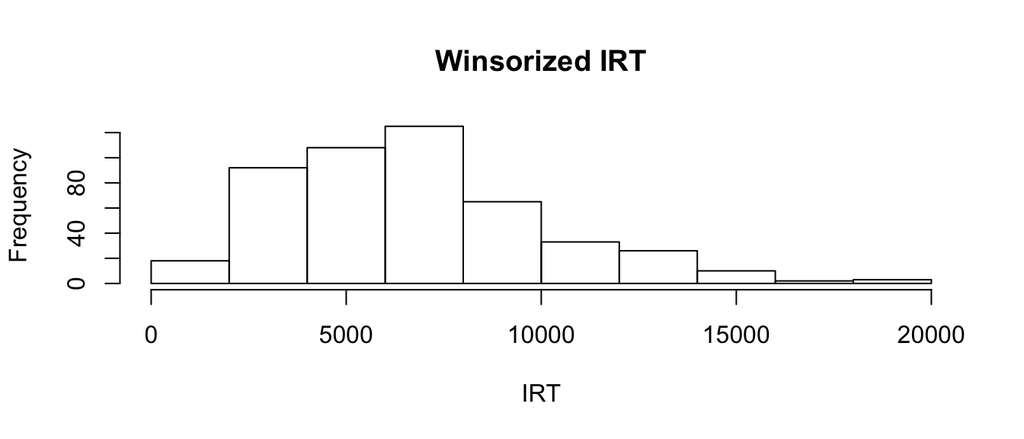

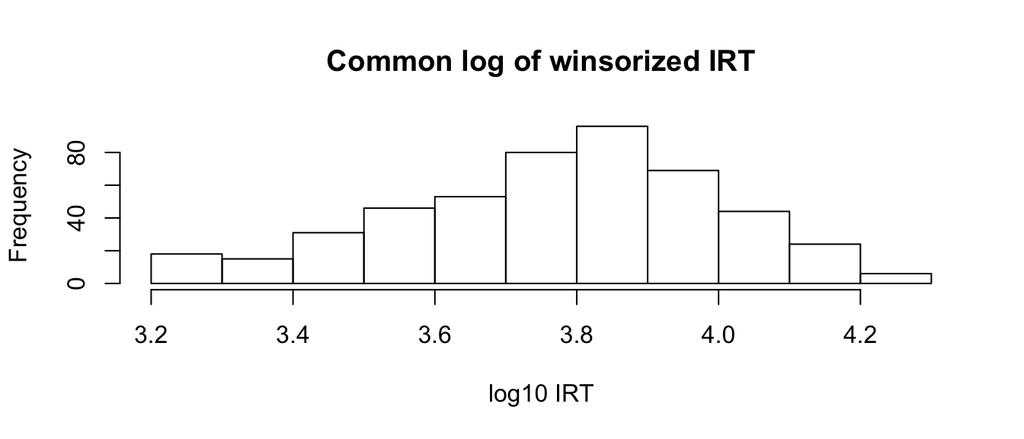

## Mean and SD of winsorized IRT by condition

If we assume that interrogative PP-attachment garden paths are easier to process as an interrogative than in the declarative, and that IRT represents how difficult a sentence is to process, we would expect the difference in mean IRT to be larger for declarative garden paths compared to declarative controls than for the same comparison of interrogatives.

Condition means

|  | Mean | SD |
| --- | --- | --- |
| -Q -GP | 6485.377 | 3217.542 |
| -Q +GP | 6672.307 | 3197.364 |
| +Q -GP | 6727.340 | 3371.999 |
| +Q +GP | 7029.643 | 3510.915 |

## Item and subject variation

There is variation across participants in terms of whether or not they show this pattern.

## Number of participants who show predicted pattern

Mean IRT by condition and participant

| participant | -Q -GP | -Q +GP | +Q -GP | +Q +GP | pattern |
| --- | --- | --- | --- | --- | --- |
| 1 | 1772.000 | 1870.75 | 1969.750 | 1892.500 | TRUE |
| 2 | 6253.333 | 7504.65 | 4269.250 | 5943.700 | TRUE |
| 3 | 4848.450 | 7033.00 | 5896.950 | 5771.600 | TRUE |
| 4 | 7652.333 | 6314.00 | 8305.500 | 11222.000 | FALSE |
| 6 | 12563.350 | 11395.35 | 11985.600 | 14141.000 | FALSE |
| 7 | 5128.500 | 5479.25 | 6059.000 | 5901.500 | TRUE |
| 8 | 4309.667 | 5002.40 | 4690.267 | 3524.000 | TRUE |
| 9 | 6095.750 | 6277.25 | 5911.250 | 6167.250 | TRUE |
| 10 | 9019.000 | 9265.00 | 8878.250 | 9488.750 | TRUE |
| 12 | 7968.000 | 8319.50 | 8084.250 | 7927.500 | TRUE |
| 13 | 8494.800 | 9518.60 | 8913.800 | 10435.850 | TRUE |
| 14 | 9034.500 | 10347.50 | 9130.000 | 12060.500 | TRUE |
| 15 | 9683.750 | 7808.25 | 9542.000 | 8610.000 | FALSE |
| 16 | 11456.000 | 10117.25 | 10247.000 | 13767.000 | FALSE |
| 17 | 4074.500 | 6155.75 | 6341.500 | 5058.750 | TRUE |
| 19 | 11476.500 | 14391.35 | 15467.300 | 15755.000 | TRUE |
| 20 | 10209.500 | 9248.00 | 11517.250 | 10013.250 | FALSE |
| 21 | 5103.500 | 4937.25 | 5398.000 | 5952.500 | FALSE |
| 22 | 5572.500 | 5161.00 | 5262.750 | 6758.500 | FALSE |
| 201 | 4065.000 | 5036.50 | 4970.750 | 4403.250 | TRUE |
| 203 | 2375.750 | 1694.25 | 1955.250 | 2501.000 | FALSE |
| 204 | 5460.750 | 6220.00 | 6605.250 | 6288.000 | TRUE |
| 205 | 9431.250 | 10142.25 | 7620.500 | 10578.000 | TRUE |
| 206 | 5094.000 | 4485.75 | 5264.500 | 4967.750 | FALSE |
| 207 | 6656.000 | 6541.75 | 6685.000 | 5464.250 | FALSE |
| 208 | 3331.750 | 3490.50 | 3007.750 | 3343.250 | TRUE |
| 209 | 3355.500 | 3729.25 | 2986.500 | 3561.250 | TRUE |
| 210 | 6600.500 | 6142.25 | 7252.250 | 6344.500 | FALSE |
| 212 | 5592.250 | 5152.50 | 5305.500 | 7267.500 | FALSE |
| 214 | 3605.300 | 5026.00 | 3449.600 | 3299.667 | TRUE |
| 215 | 4452.500 | 3746.00 | 5065.750 | 4746.250 | FALSE |

## Number of items that show predicted pattern

Mean IRT by condition and item

| item | -Q -GP | -Q +GP | +Q -GP | +Q +GP | pattern |
| --- | --- | --- | --- | --- | --- |
| 1 | 6336.550 | 7091.029 | 7636.286 | 7835.500 | TRUE |
| 2 | 7373.400 | 8510.475 | 4531.850 | 6665.257 | TRUE |
| 3 | 7082.575 | 6833.800 | 5448.375 | 7520.571 | FALSE |
| 4 | 8087.314 | 7502.700 | 7728.743 | 5564.000 | FALSE |
| 5 | 6566.333 | 6964.350 | 5984.500 | 5034.667 | TRUE |
| 6 | 7147.500 | 6139.250 | 6383.000 | 6402.625 | FALSE |
| 7 | 7234.429 | 7177.875 | 7190.925 | 8054.000 | FALSE |
| 8 | 5655.143 | 5796.350 | 6086.275 | 7493.500 | TRUE |
| 9 | 5316.625 | 7607.171 | 7424.000 | 9465.829 | TRUE |
| 10 | 7114.150 | 7355.125 | 6091.300 | 5641.600 | TRUE |
| 11 | 4960.686 | 4704.429 | 6697.375 | 8483.714 | FALSE |
| 12 | 4605.625 | 5708.714 | 7103.025 | 7850.625 | TRUE |
| 13 | 7647.714 | 5553.375 | 7771.525 | 8034.333 | FALSE |
| 14 | 6174.300 | 6368.000 | 7245.714 | 6046.875 | TRUE |
| 15 | 4937.350 | 6275.286 | 7086.325 | 6118.143 | TRUE |
| 16 | 7691.375 | 6922.125 | 7597.543 | 6011.175 | FALSE |

# Analyses

The following models explore the effect of garden path (±GP) and interrogativeness (±Q) on IRT.

## Regression analyses

A full model with random slopes for GP, Q, and their interaction for both error terms fails to converge. A model with random slopes for just GP `+` Q likewise fails to converge. Simple models with no random slopes are shown below.

|  | inter reading log 10 |  |  | inter reading log 10 |  |  |
| --- | --- | --- | --- | --- | --- | --- |
| Predictors | Estimates | CI | p | Estimates | CI | p |
| (Intercept) | 3.76 | 3.68 – 3.83 | **<0.001** | 3.75 | 3.68 – 3.83 | **<0.001** |
| GP_conditionTRUE | 0.02 | -0.01 – 0.04 | 0.180 | 0.02 | 0.00 – 0.04 | **0.022** |
| Q_conditionTRUE | 0.01 | -0.01 – 0.04 | 0.277 | 0.02 | -0.00 – 0.04 | 0.052 |
| GP_conditionTRUE:Q_conditionTRUE | 0.01 | -0.03 – 0.05 | 0.670 |  |  |  |
| Random Effects |  |  |  |  |  |  |
| σ<sup>2</sup> | 0.01 |  |  | 0.01 |  |  |
| τ<sub>00</sub> | 0.04 <sub>participant</sub> |  |  | 0.04 <sub>participant</sub> |  |  |
|  | 0.00 <sub>item</sub> |  |  | 0.00 <sub>item</sub> |  |  |
| ICC | 0.78 <sub>participant</sub> |  |  | 0.78 <sub>participant</sub> |  |  |
|  | 0.00 <sub>item</sub> |  |  | 0.00 <sub>item</sub> |  |  |
| Observations | 482 |  |  | 482 |  |  |
| Marginal R<sup>2</sup> / Conditional R<sup>2</sup> | 0.004 / 0.787 |  |  | 0.004 / 0.787 |  |  |

The interaction model does not represent a statistically significant improvement in fit (Χ<sup>2</sup> = 0.182, p < 0.67), and so does not support the primary hypothesis.

The simplified model still does not show a statstically significant interaction.

|  | inter reading log 10 |  |  |
| --- | --- | --- | --- |
| Predictors | Estimates | CI | p |
| (Intercept) | 3.76 | 3.68 – 3.83 | **<0.001** |
| GP_conditionTRUE | 0.02 | -0.01 – 0.05 | 0.180 |
| Q_conditionTRUE | 0.01 | -0.01 – 0.04 | 0.282 |
| GP_conditionTRUE:Q_conditionTRUE | 0.01 | -0.03 – 0.05 | 0.683 |
| Random Effects |  |  |  |
| σ<sup>2</sup> | 0.01 |  |  |
| τ<sub>00</sub> <sub>participant</sub> | 0.04 |  |  |
| ICC <sub>participant</sub> | 0.78 |  |  |
| Observations | 482 |  |  |
| Marginal R<sup>2</sup> / Conditional R<sup>2</sup> | 0.004 / 0.783 |  |  |

Removing the random effect of item does not degrade the model in a stastically significant way (Χ<sup>2</sup> = 1.14, p = 0.29), but removing the random effect of participant does (Χ<sup>2</sup> = 611.28, p = 0).

## GEE Analyses

Generalized Estimating Equation (GEE) analyses with participant as the error term show much the same results.

|  | inter reading log 10 |  |  | inter reading log 10 |  |  |
| --- | --- | --- | --- | --- | --- | --- |
| Predictors | Estimates | CI | p | Estimates | CI | p |
| (Intercept) | 3.76 | 3.68 – 3.83 | **<0.001** | 3.75 | 3.68 – 3.83 | **<0.001** |
| GP_conditionTRUE | 0.02 | -0.01 – 0.04 | 0.216 | 0.02 | -0.00 – 0.04 | 0.055 |
| Q_conditionTRUE | 0.02 | -0.01 – 0.04 | 0.212 | 0.02 | -0.00 – 0.03 | 0.052 |
| GP_conditionTRUE:Q_conditionTRUE | 0.00 | -0.04 – 0.05 | 0.900 |  |  |  |
| Observations | 482 |  |  | 482 |  |  |

The interaction model does not represent a statistically significant improvement in fit (Χ = 0.016, p < 0.9), and so does not support the primary hypothesis.

# Excluding items

If we exclude items where the IRT for the control condition (-Q, -GP) is longer than 7s, we get the following:

Difference for declaratives: 378.09; for interrogatives: 809.48; difference of differences: -431.39.

Condition means

|  | Mean | SD |
| --- | --- | --- |
| -Q -GP | 6527.698 | 3912.822 |
| -Q +GP | 6905.787 | 3831.170 |
| +Q -GP | 6768.328 | 4157.561 |
| +Q +GP | 7577.808 | 4389.617 |

## GEE Analyses

Generalized Estimating Equation (GEE) analyses with participant as the error term show much the same results.

|  | Dependent variable |  |  | Dependent variable |  |  |
| --- | --- | --- | --- | --- | --- | --- |
| Predictors | Estimates | CI | p | Estimates | CI | p |
| (Intercept) | 3.73 | 3.66 – 3.81 | **<0.001** | 3.73 | 3.66 – 3.80 | **<0.001** |
| GP_conditionTRUE | 0.03 | -0.01 – 0.08 | 0.134 | 0.05 | 0.02 – 0.08 | **0.001** |
| Q_conditionTRUE | 0.01 | -0.05 – 0.07 | 0.817 | 0.02 | -0.02 – 0.06 | 0.341 |
| GP_conditionTRUE:Q_conditionTRUE | 0.03 | -0.05 – 0.11 | 0.478 |  |  |  |
| Observations | 501 |  |  | 501 |  |  |

|  | Dependent variable |  |  | Dependent variable |  |  |
| --- | --- | --- | --- | --- | --- | --- |
| Predictors | Estimates | CI | p | Estimates | CI | p |
| (Intercept) | 3.73 | 3.68 – 3.78 | **<0.001** | 3.73 | 3.68 – 3.77 | **<0.001** |
| GP_conditionTRUE | 0.03 | -0.03 – 0.10 | 0.328 | 0.05 | -0.00 – 0.10 | 0.060 |
| Q_conditionTRUE | 0.01 | -0.07 – 0.08 | 0.851 | 0.02 | -0.03 – 0.07 | 0.410 |
| GP_conditionTRUE:Q_conditionTRUE | 0.03 | -0.07 – 0.13 | 0.581 |  |  |  |
| Observations | 501 |  |  | 501 |  |  |

The interaction model does not represent a statistically significant improvement in fit (Χ = 0.504, p < 0.48), and so does not support the primary hypothesis.